# MRL Equipment Usage Report

Jun

January 23, 2016

## MRL @Illinois

The materials research laboratory (MRL) is an interdisciplinary research laboratory focused on fundamental issues in materials science. It hosts a large collection of equipments for researchers to use. I, as a graduate student focusing on nanoscale heat transfer in materials, have been using the micro fabrication tools since I started. However, recently many of the tools I use have been down for a prolonged time. This is frustrating especially when I am finishing up my last set of experiments for my PhD defense. So, I decided to scrape the data from MRL instrument schedule and see how much usage for each tool in the past year.

## Data type

Let’s first take a look at the webpage.

[figure not shown]

The data stored in this page is in an HTML table. However, the table only gives the text info on the schedule.

```r
library(XML)
library(dplyr)
library(ggplot2)
library(knitr)
library(lubridate)

usage.url <- 'http://cmmserv.mrl.illinois.edu/microfabschedule/guest/npTimeSlots.asp?BW=2016-01-17&GI=0'
usage <- htmlTreeParse(usage.url, error=function(...){}, useInternalNodes = TRUE)
readHTMLTable(usage, as.data.frame=TRUE, stringsAsFactors=FALSE)[[1]]
```

```
##   12:00AM Sun Mon Tue Wed -- SHANG Fri Sat
## 1 12:30AM Sun Mon Tue Wed      Thu Fri Sat
## 2 01:00AM Sun Mon Tue Wed      Thu Fri Sat
## 3 01:30AM Sun Mon Tue Wed      Thu Fri Sat
## 4 02:00AM Sun Mon Tue Wed      Thu Fri Sat
## 5 02:30AM Sun Mon Tue Wed      Thu Fri Sat
## 6 03:00AM Sun Mon Tue Wed      Thu Fri Sat
## 7 03:30AM Sun Mon Tue Wed      Thu Fri Sat
```

To get the time slots that have been booked, I need to go into the file and look for bgcolor attributes using the following code `inUse <- length(xpathSApply(usage, "//td[@bgcolor !='#FFFFFF']",xmlValue))`. Once I have the time slots with `bgcolor != '#FFFFFF'`, the total booked time of that week can be calculated by $Number_{nonwhite} \times 0.5 hr$. Now let’s find all the equipments and loop through past year.

## Usage in past year

To get the equipment list:

```r
eq.url <- "http://cmmserv.mrl.illinois.edu/microfabschedule/guest/npMonthView.asp?QM=1&QY=2016&GI=0"
eq <- htmlTreeParse(eq.url, error=function(...){}, useInternalNodes = TRUE)
eq <- xpathSApply(eq,"//select[@name ='GI']/option",xmlValue)

eq.df <- data.frame(GI = seq(0, 38, by = 1), equipment = eq)
head(eq.df)
```

```
##   GI            equipment
## 1  0         Raith e-Line
## 2  1   AJA Sputter Coater
## 3  2 AJA Sputter Coater 2
## 4  3  E-beam Evaporator 1
## 5  4  E-beam Evaporator 2
## 6  5  E-beam Evaporator 3
```

To find all the booked time slots as well as down time for each equipment:

```r
dates <- seq(from=as.Date("2015-01-01"), to=as.Date("2016-01-23"), by="day")

dates <- strptime(dates, "%Y-%m-%d")
sunday <- as.character(format(dates[dates$wday==0], '%D'))
usage.df <- data.frame(matrix(ncol = 4, nrow = 0))


for (i in eq.df[,1]){

  for (day in sunday){
  usage.url <- paste('http://cmmserv.mrl.illinois.edu/microfabschedule/guest/npTimeSlots.asp?BW=', day, '&GI=', i, sep = '')
  usage <- htmlTreeParse(usage.url, error=function(...){}, useInternalNodes = TRUE)
  inUse <- length(xpathSApply(usage, "//td[@bgcolor !='#FFFFFF']",xmlValue))
  down <- length(c(xpathSApply(usage, "//td[@bgcolor ='#999999']",xmlValue), xpathSApply(usage, "//td[@bgcolor ='#777777']",xmlValue)))
  use.time <- inUse * 0.5
  down.time <- down*0.5
  usage.df<- rbind(usage.df, data.frame(day, as.character(eq.df[i+1, 2]), use.time, down.time, use.time-down.time))
}
}

colnames(usage.df) <- c('startingSunday', 'equipment', 'hours', 'down', 'realHours')
```

Let’s plot the equipments that have been used over 100 hours in the past year.

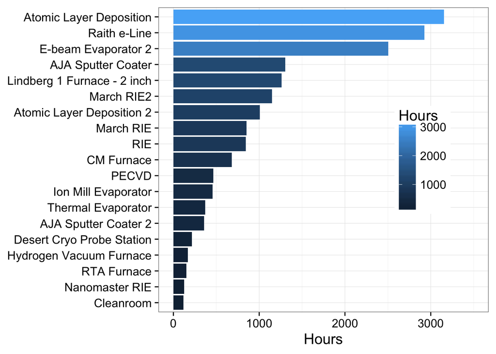

```r
usage.by.eq <- usage.df %>%
  group_by(equipment) %>%
  summarise(hours = sum(hours), down = sum(down), realHours = sum(realHours)) %>%
  arrange(realHours)

filtered <- filter(usage.by.eq, realHours>100)

ggplot(data = filtered, aes(x=equipment, y=realHours, fill = realHours)) + geom_bar(stat = 'identity') +
  scale_x_discrete(limits=unique(filtered$equipment)) + coord_flip() +
  scale_fill_continuous(name="Hours") + ylab('Hours') +
  ylim(0, 3500) + theme_bw(15) + theme(axis.title.y = element_blank(), legend.position = c(0.8, 0.5))
```

And the equipments suffered a significant amount of down times.

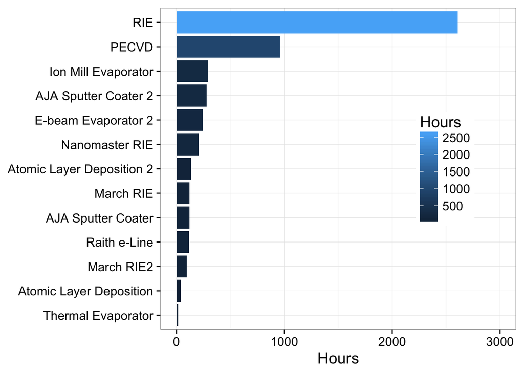

```r
filtered <- filtered %>%
  filter(down>0) %>%
  arrange(down)

ggplot(data = filtered, aes(x=equipment, y=down, fill = down)) + geom_bar(stat = 'identity') +
  scale_x_discrete(limits=unique(filtered$equipment)) + coord_flip() +
  scale_fill_continuous(name="Hours") + ylab('Hours') +
  ylim(0, 3000) + theme_bw(15) + theme(axis.title.y = element_blank(), legend.position = c(0.8, 0.5))
```

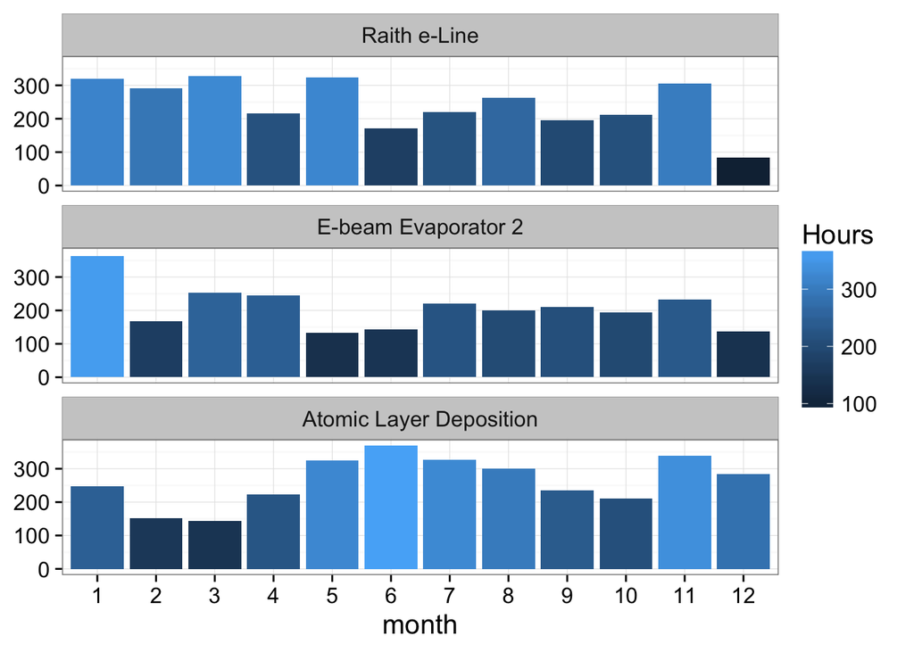

```r
usage.by.month <- usage.df %>%
  mutate(month = month(as.Date(startingSunday, "%m/%d/%y"))) %>%
  group_by(equipment, month) %>%
  summarise(hours = sum(hours), down = sum(down), realHours = sum(realHours)) %>%
  filter(equipment %in% c('Atomic Layer Deposition', 'Raith e-Line', 'E-beam Evaporator 2'))

ggplot(data = usage.by.month, aes(x=month, y=realHours, fill = realHours)) + geom_bar(stat = 'identity') +
  scale_x_discrete(limits=unique(usage.by.month$month)) +
  facet_wrap(~equipment, ncol = 1) +
  scale_fill_continuous(name="Hours") +
  theme_bw(15) + theme(axis.title.y = element_blank())
```